# documentation

```python
import itertools
import random
import os
import sys

import numpy as np
import matplotlib.pyplot as plt
import scipy as sp
import pandas as pd

import networkx as nx


import matplotlib.pyplot as plt

import warnings
warnings.filterwarnings('ignore')
```

```python
# This class represents a directed graph using adjacency list representation.
class Graph:
    def __init__(self, vertices=None, oriented=False):
        self.adjacency_list = defaultdict(list)
        self.oriented = oriented

        if vertices is not None:
            for kvertex, vlist in vertices.items():
                self.adjacency_list[kvertex] = vlist
                #print(kvertex, vlist)
                if oriented:
                    for vertex in vlist:
                        if kvertex not in self.adjacency_list[vertex]:
                            self.adjacency_list[vertex].append(kvertex)

        #print(self.adjacency_list["230612164"])

    def __contains__(self, vertex):
        return vertex in self.adjacency_list.keys()

    def __getitem__(self, vertex):

        result = set(self.adjacency_list.get(vertex))
        for v, adj_vlist in self.adjacency_list.items():
            if vertex in adj_vlist:
                result.add(v)
        return result

    def get_edges(self):
        result = []
        for u in self.adjacency_list.keys():
            l = [(u, v) for v in self[u]
                 if (u, v) not in result and
                     (v, u) not in result]
            result.extend(l)
        return result

    def get_degrees(self):
        result = {v: len(self[v]) for v in self.adjacency_list.keys()}
        return result

    def degree(self, vertex):
        if vertex not in vertex in self:
            raise ValueError("Vertex is not in the graph.")

        return len(self[vertex])

    # Function to add an edge to graph.
    def add_edge(self, u, v):
        self.adjacency_list[u].append(v)
        if v not in self:
            self.adjacency_list[v] = []
        if self.oriented:
            self.adjacency_list[v].append(u)

    # Function that returns reverse (or transpose) of this graph.
    def get_transpose(self):
        g = Graph(oriented=self.oriented)
        # Recur for all the vertices adjacent to this vertex.
        for i, i_list in self.adjacency_list.items():
            for j in i_list:
                g.add_edge(j, i)
        return g

    # A function used to perform DFS.
    def dfs_util(self, v, visited, stack=None, output=False):
        # Mark the current node as visited.
        visited[v] = True
        if output:
            print(v, end=" ")

        # Recur for all the vertices adjacent to this vertex.
        for i in self.adjacency_list[v]:
            if not visited[i]:
                self.dfs_util(i, visited, stack, output)
        if stack is not None:
            stack.append(v)

    # Function that returns true if graph is strongly connected.
    def is_strongly_connected(self):
        return (len(self.get_strongly_connected_components()[0]) ==
                len(self.adjacency_list))

    # Function that finds and prints all strongly connected components.
    def get_strongly_connected_components(self, output=False):
        stack = []
        # Mark all the vertices as not visited (For first DFS).
        visited = {key: False for key in self.adjacency_list.keys()}
        visited = {}
        for key in self.adjacency_list.keys() :
            visited[key] = False
        # Fill vertices in stack according to their finishing times.
        for i in self.adjacency_list.keys():
            if not visited[i]:
                self.dfs_util(i, visited, stack=stack)

        # Create a reversed graph.
        reversed_graph = self.get_transpose()

        # Mark all the vertices as not visited (For second DFS).
        visited = {key: False for key in self.adjacency_list.keys()}

        sc_components = defaultdict(list)
        counter = 0
        # Now process all vertices in order defined by Stack.
        while stack:
            i = stack.pop()
            if not visited[i]:
                i_stack = []
                reversed_graph.dfs_util(i, visited, stack=i_stack,
                                        output=output)
                sc_components[counter].extend(i_stack)
                counter += 1
                if output:
                    print()
        return sc_components

    # Function that returns true if graph is strongly connected.
    def is_weakly_connected(self):
        return (len(self.get_weakly_connected_components()[0]) ==
                len(self.adjacency_list))

    # Method to retrieve connected components in graph.
    def get_weakly_connected_components(self, output=False):
        visited = {key: False for key in self.adjacency_list.keys()}
        wc_components = defaultdict(list)
        counter = 0
        for v in self.adjacency_list.keys():
            if not visited[v]:
                v_stack = []
                self.dfs_util(v, visited, stack=v_stack, output=output)
                wc_components[counter].extend(v_stack)
                counter += 1
                if output:
                    print()
        return wc_components

    def get_subgraph(self, vertex_labels):
        subgraph = Graph()
        for vertex_label in vertex_labels:
            vertex_list = self.adjacency_list.get(vertex_label)
            if vertex_list is not None:
                subgraph.adjacency_list[vertex_label].extend(vertex_list)
        return subgraph


def check_graph_connectivity(graph, output=True):
    print(f"Strongly connected: {graph.is_strongly_connected()}")
    print(f"Weakly connected: {graph.is_weakly_connected()}")
    graph.get_strongly_connected_components(output=output)
    if output:
        print()
    graph.get_weakly_connected_components(output=output)
    if output:
        print()
```

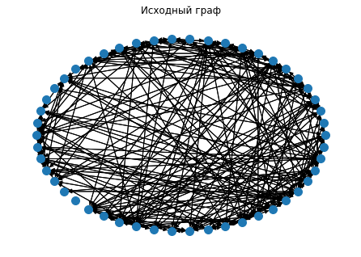

```python
G = nx.read_gexf('./../vk-friends-137252115.gexf')
def save_from_plt(path, title="", axis=False, xlabel="", ylabel=""):
    if axis:
        plt.xlabel(xlabel)
        plt.ylabel(ylabel)
        plt.axis("auto")
    else:
        plt.axis("off")
    plt.title(title)
    plt.savefig(path)


nx.draw_circular(G, with_labels=False, node_size=100,
                     label="Graph")
save_from_plt("../task1/original_graph.png", title="Исходный граф")
```

```python
nx.write_adjlist(G,"./../list_adjacency.csv")
```

```python
adjacency_matrix = nx.to_numpy_matrix(G)
type(adjacency_matrix), len(adjacency_matrix)
```

```
(numpy.matrix, 50)
```

```python
adjacency_list = nx.to_dict_of_lists(G)
type(adjacency_list), len(adjacency_list)
```

```
(dict, 50)
```

```python
from collections import defaultdict
```

```python
social_graph = Graph(adjacency_list)
sc_components_graph = social_graph.get_strongly_connected_components()
wc_components_graph = social_graph.get_weakly_connected_components()
print("Размер графа:", len(social_graph.adjacency_list))
print("Число компонент сильной связности:", len(sc_components_graph))
print("Set of strongly connected component lengths",
      [len(component) for component in sc_components_graph.values()])
print("Число компонент слабой связности:", len(wc_components_graph))
print("Число вершин в компонетах слабой связности",
      [len(component) for component in wc_components_graph.values()])
```

[output not shown]

```python
max_sc_component = max(sc_components_graph.values(), key=len)
max_wc_component = max(wc_components_graph.values(), key=len)
print("Число вершин в наибольшей компоненте сильной связности:",
      len(max_sc_component))
print("Число вершин в наибольшей компоненте слабой связности:",
      len(max_wc_component))
```

```
Число вершин в наибольшей компоненте сильной связности: 48
Число вершин в наибольшей компоненте слабой связности: 48
```

# Task 2

Выбираем компоненту связности с наибольшим числом вершин.

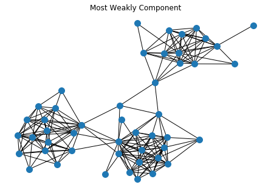

```python
social_subgraph = social_graph.get_subgraph(max_wc_component)

subgraph_nx = nx.Graph(social_subgraph.adjacency_list)
nx.draw_kamada_kawai(subgraph_nx, with_labels=False, node_size=100,
                     label="Most Weakly Component")
save_from_plt("../task2/social_sub_graph.png","Most Weakly Component")
```

Строим гистрограмму плотности вероятности распределения.

```
Средняя степень вершин: 8.333333333333334
```

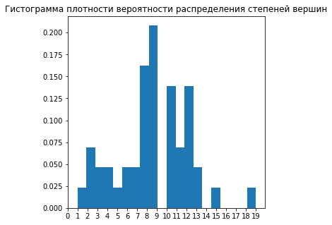

```python
from statistics import mean
from collections import Counter
adjacency_list_main =social_subgraph.adjacency_list
v_degrees = defaultdict(int, ((n, len(v)) for n, v in
                                   adjacency_list_main.items()))
v_degrees_statistic = Counter(v_degrees.values())
average = mean(v_degrees_statistic.keys())
print("Средняя степень вершин:",average)
fig, ax = plt.subplots(1, 1, figsize=(5, 5))
ax.hist(v_degrees.values(), bins=max(v_degrees.values())+1, density=True)
ax.set_title('Гистограмма плотности вероятности распределения степеней вершин')
ax.set_xticks(range(max(v_degrees.values())+1))
plt.savefig('../task2/histogram.png')
plt.show()
```

### Матрица расстояний

```python
max_weekly_adjacency_matrix = nx.Graph(social_subgraph.adjacency_list)
matrix_path = nx.to_numpy_matrix(max_weekly_adjacency_matrix, nonedge=np.inf)
print(matrix_path)
```

```
[[inf inf inf ... inf inf inf]
 [inf inf inf ... inf inf inf]
 [inf inf inf ... inf inf inf]
 ...
 [inf inf inf ... inf  1. inf]
 [inf inf inf ...  1. inf  1.]
 [inf inf inf ... inf  1. inf]]
```

Найдем матрицу кратчайших путей с помощью алгоритма Флойда-Уоршелла $O(|V|^3)$

```python
n = matrix_path.shape[0]
for k in range(n):
    for i in range(n):
        for j in range(n):
            matrix_path[i, j] = min(matrix_path[i, k]
                                              + matrix_path[k, j],
                                                 matrix_path[i, j])
print(matrix_path)
```

```
[[2. 2. 2. ... 5. 5. 4.]
 [2. 2. 2. ... 6. 6. 5.]
 [2. 2. 2. ... 5. 5. 4.]
 ...
 [5. 6. 5. ... 2. 1. 2.]
 [5. 6. 5. ... 1. 2. 1.]
 [4. 5. 4. ... 2. 1. 2.]]
```

### Эксцентриситет графа

Эксцентриситет графа - расстояние до самой дальней вершины графа

```python
eccentricity = matrix_path.max(axis=1).astype(int)
print(eccentricity)
```

```
[[6]
 [7]
 [6]
 [5]
 [6]
 [6]
 [5]
 [6]
 [6]
 [5]
 [5]
 [6]
 [5]
 [6]
 [6]
 [5]
 [5]
 [5]
 [4]
 [4]
 [7]
 [6]
 [6]
 [7]
 [7]
 [6]
 [6]
 [6]
 [6]
 [6]
 [6]
 [6]
 [6]
 [6]
 [6]
 [5]
 [4]
 [6]
 [5]
 [6]
 [6]
 [6]
 [6]
 [6]
 [5]
 [6]
 [6]
 [5]]
```

### Радиус графа

Радиусом графа - минимальный эксцентриситет среди всех вершин графа

```python
radius = np.min(eccentricity)
print(radius)
```

```
4
```

### Диаметр графа

Диаметр графа - наибольший эксцентриситет среди всех вершин графа

```python
diameter = int (np.max(eccentricity))
print(diameter)
```

```
7
```

### Множество переферийных вершин

Периферийная вершина графа - вершина чей эксцентриситет равен диаметру графа.

```python
array_peref,_ = np.where(eccentricity==diameter)
print(array_peref)
```

```
[ 1 20 23 24]
```

### Множество центральных вершин

Центральная вершина графа - вершина чей эксцентриситет равен радиусу графа.

```python
array_center, _ = np.where(eccentricity==radius)

print(array_center)
```

```
[18 19 36]
```

### Средняя длина пути

```python
mean_distance =matrix_path.mean()
print('Средняя длина пути в графе: {0:.3f}'.format( mean_distance))
```

```
Средняя длина пути в графе: 2.982
```

# Task 3

### Common Neighbors

$N(x)$ - количество вершин смежных вершине $x$.

Common Neighbors $(x, y) = |N(x) \cap N(y)|$

```python
social_subgraph = social_graph.get_subgraph(max_wc_component)
max_weekly_adjacency_matrix = nx.Graph(social_subgraph.adjacency_list)
adjacency_matrix_main = nx.to_numpy_matrix(max_weekly_adjacency_matrix,dtype=int)
```

```python
common_neighbors = np.zeros(shape=(n, n), dtype=int)
for i in range(n):
    for j in itertools.chain(range(i), range(i+1, n)):
        common_neighbors[i, j] = common_neighbors[j, i] = \
            np.sum(adjacency_matrix_main[i] & adjacency_matrix_main[j])
```

[output not shown]

### Jaccard’s Coefficient (мера Жаккара)

Jaccard’s Coefficient $(x, y) = \frac{|N(x) \cap N(y)|}{|N(x) \cup N(y)|}$

```python
jaccards_coefficient = np.zeros(shape=(n, n), dtype=float)

for i in range(n):
    for j in itertools.chain(range(i), range(i+1, n)):
        intersection = np.sum(adjacency_matrix_main[i] & adjacency_matrix_main[j])
        union = np.sum(adjacency_matrix_main[i] | adjacency_matrix_main[j])
        jaccards_coefficient[i, j] = jaccards_coefficient[j, i] = np.round(intersection/union, 2)
```

### Adamic/Adar (Frequency-Weighted Common Neighbors)

Frequency-Weighted Common Neighbors $(x, y) = \sum_{z \in N(x) \cap N(y)} \frac{1}{log(N(z))}$

```python
fw_common_neighbors = np.zeros(shape=(n, n), dtype=float)

for i in range(n):
    for j in itertools.chain(range(i), range(i+1, n)):
        intersection = np.intersect1d(adjacency_matrix_main[i],adjacency_matrix_main[j])
        intersection = np.squeeze(np.asarray(intersection))
        fw_common_neighbors[i, j] = fw_common_neighbors[j, i] = np.round(\
            np.sum(1 / np.log([np.sum(adjacency_matrix[vertex]) for vertex, flug in
                 enumerate(intersection) if flug])), 2)
print(adjacency_matrix_main.shape)
```

```
(48, 48)
```

### Preferential Attachment

Preferential Attachment $(x, y) = |N(x)| \times |N(y)|$

```python
preferential_attachment  = np.zeros(shape=(n, n), dtype=int)

for i in range(n):
    for j in itertools.chain(range(i), range(i+1, n)):
        preferential_attachment[i, j] = preferential_attachment[j, i] = \
            np.sum(adjacency_matrix_main[i]) * np.sum(adjacency_matrix_main[j])
```

```python
with open('./../report/task 3/preferential attachment.csv', 'w') as f:
    f.write(',' + ','.join(str(x) for x in range(len(preferential_attachment))) + '\n')
    for vertex in range(len(preferential_attachment)):
        f.write(str(vertex) + ',' + ','.join(str(x) for x in preferential_attachment[vertex]) + '\n')
```

### Сохранение результатов

```python
np.savetxt("../task3/common_neighbors.csv",common_neighbors, delimiter=",")
np.savetxt("../task3/jaccards_coefficient.csv",jaccards_coefficient, delimiter=",")
np.savetxt("../task3/fw_common_neighbors.csv",fw_common_neighbors, delimiter=",")
np.savetxt("../task3/preferential attachment.csv",preferential_attachment, delimiter=",")
#pd.DataFrame(preferential_attachment).to_csv("../task1/preferential attachment.csv")
```

# Task 4

```python
nx_graph = nx.Graph(social_subgraph.adjacency_list)
def draw_graph_with_centrality(G,centrality) :
    n = len(social_subgraph.adjacency_list)
    max_value = max(centrality.values())
    min_value = min(centrality.values())
    rgba_colors = np.zeros((n,3))
    rgba_colors[:,2] = (np.array([x for x in centrality.values()])-min_value)/(max_value-min_value)
    nx_graph = nx.Graph(social_subgraph.adjacency_list)
    nx.draw_kamada_kawai(nx_graph, cmap=plt.cm.Reds, node_color=rgba_colors,
                         node_size=100, with_labels=False, label="Graph")
```

### Degree centrality

Центральность вершины по степени - отношение числа инцидентных вершине ребер к числу вершин в графе.

normal g(v) = $\frac{g(x) - min g(x)}{\ max g(x) - min g(x)}$,

$d(u, v)$ - длина кратчайшего пути из $u$ в $v$. Визуализируем метрику

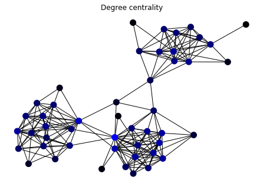

```python
degree_centrality = {vertex: np.sum(adjacency_matrix_main[vertex]) / (len(G)-1) for vertex in range(adjacency_matrix_main.shape[0])}
draw_graph_with_centrality(nx_graph,degree_centrality)
save_from_plt("../task4/degree_centrality.png","Degree centrality")
```

### Closeness centrality

Центральность вершины по близости - отношение числа вершин - 1 к сумме длин кратчайших путей к данной вершине из вершин графа.

closeness centrality(v) = $\frac{|V| - 1}{\sum_{u \in V(G)} d(u, v)}$,

$d(u, v)$ - длина кратчайшего пути из $u$ в $v$.

[output not shown]

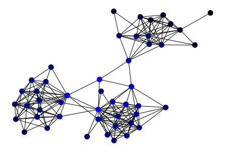

```python
spmd =matrix_path.copy()
np.fill_diagonal(spmd,0)
closeness_centrality = {vertex: (adjacency_matrix_main.shape[0]-1) / np.sum(paths) for vertex, paths in enumerate(spmd)}
draw_graph_with_centrality(nx_graph,closeness_centrality)
save_from_plt("../task4/closeness_centrality.png","Closeness centrality")
```

### Betweenness centrality (nodes)

betweenness centrality $(v)$ = $\sum_{s, t \in V(G)} \frac{\sigma(s,t|v)}{\sigma(s, t)}$

$\sigma(s,t)$ - количество кратчайших $(s,t)$ - путей.

$\sigma(s,t|v)$ - количество кратчайших $(s,t)$ - путей, проходящих через вершину $v$.

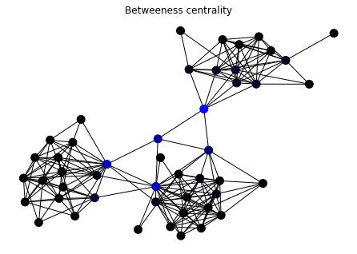

```python
def shortest_path(graph, source):
    order = []
    # predecessors of every vertex
    predeccessors = {}
    for v in graph.adjacency_list.keys():
        predeccessors[v] = []
    # sigma[v] = 0 for v in G
    shortest_lenth = dict.fromkeys(graph.adjacency_list.keys(), 0.0)
    # depth of BFS
    D = {}
    shortest_lenth[source] = 1.0
    D[source] = 0
    Q = [source]
    #  find shortest paths by BFS
    while Q:
        v = Q.pop(0)
        order.append(v)
        Dv = D[v]
        sigmav = shortest_lenth[v]
        for w in graph[v]: # not visited
            if w not in D:
                Q.append(w)
                #save shortest paht to vertex
                D[w] = Dv + 1
            if D[w] == Dv + 1:  # this is a shortest path
                shortest_lenth[w] += sigmav # number of shortest path to w
                # Predecessors.
                predeccessors[w].append(v)
    return order, predeccessors, shortest_lenth

def accumulate_basic(betweenness, order, predeccessors, shortest_path, source):
    delta = dict.fromkeys(order, 0)
    while order:
        w = order.pop()
        coeff = (1 + delta[w]) / shortest_path[w]
        for v in predeccessors[w]:
            delta[v] += shortest_path[v] * coeff
        if w != source:
            betweenness[w] += delta[w]
    return betweenness

def betweenness_centrality(graph,normalized=False):

    n = len(graph.adjacency_list)
    betweenness = dict.fromkeys(graph.adjacency_list.keys(), 0.0)
    for s in graph.adjacency_list:
        # Single source shortest paths using BFS.
        order, predeccessors, shortest_lenth = shortest_path(graph, s)
        # Accumulation.
        betweenness = accumulate_basic(betweenness, order, predeccessors, shortest_lenth, s)
    # Rescale by 2 for undirected graphs.
    if normalized:              # normalization
        for v in betweenness.keys():
            betweenness[v] /= (n-1)*(n-2)
    return betweenness

betweenness_centrality = betweenness_centrality(social_subgraph)
draw_graph_with_centrality(nx_graph, betweenness_centrality)
save_from_plt("../task4/betweenness_centrality.png","Betweeness centrality")
```

### Edge Betweenness Centrality

betweenness centrality $(v)$ = $\sum_{s, t \in V(G)} \frac{\sigma(s,t|e)}{\sigma(s, t)}$

$\sigma(s,t)$ - количество кратчайших $(s,t)$ - путей.

$\sigma(s,t|v)$ - количество кратчайших $(s,t)$ - путей, проходящих через ребро $e$.

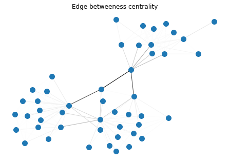

```python
def accumulate_edges(betweenness, S, P, sigma, s):
    delta = dict.fromkeys(S, 0)
    while S:
        w = S.pop()
        coeff = (1 + delta[w]) / sigma[w]
        for v in P[w]:
            c = sigma[v] * coeff
            if (v, w) not in betweenness:
                betweenness[(w, v)] += c
            else:
                betweenness[(v, w)] += c
            delta[v] += c
        if w != s:
            betweenness[w] += delta[w]
    return betweenness


def edge_betweenness_centrality(graph):
    # b[v] = 0 for v in G.
    betweenness = dict.fromkeys(graph.adjacency_list.keys(), 0.0)
    # b[e] = 0 for e in Edges.
    betweenness.update(dict.fromkeys(graph.get_edges(), 0.0))
    for s in graph.adjacency_list.keys():
        # Single source shortest paths using BFS.
        S, P, sigma = shortest_path(graph, s)
        # Accumulation.
        betweenness = accumulate_edges(betweenness, S, P, sigma, s)
    # Remove nodes to only return edges.
    for n in graph.adjacency_list.keys():
        del betweenness[n]
    # Rescale by 2 for undirected graphs.
    scale = 0.5
    for v in betweenness.keys():
        betweenness[v] *= scale
    return betweenness

edge_betweennes = edge_betweenness_centrality(social_subgraph)
values = [edge_betweennes.get(edge, 0.0) for edge in nx_graph.edges()]
nx.draw_kamada_kawai(nx_graph, edge_cmap =plt.cm.Greys,
                         edge_color=values, node_size=100, with_labels=False,
                         label="Graph")
save_from_plt("../task4/edge_betweeness_centrality.png","Edge betweeness centrality")
```

### Eigenvector centrality

Eigenvector centrality вершины - значение соответствующей компоненты вектора $x$.

$$Ax=\lambda x$$

где $A$ - матрица смежности графа

Получаем несколько возможных значений собственных векторов.

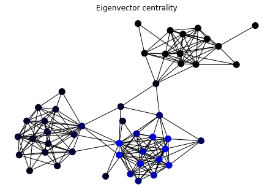

```python
def eigenvector_centrality(graph, max_iter=100, tol=1e-06):
    # Start with the all-ones vector.
    nstart = {v: 1 for v in graph.adjacency_list.keys()}
    # Normalize the initial vector so that each entry is in [0, 1]. This is
    # guaranteed to never have a divide-by-zero error by the previous line.
    nstart_sum = sum(nstart.values())
    x = {k: v / nstart_sum for k, v in nstart.items()}
    nnodes = len(graph.adjacency_list.keys())
    # make up to max_iter iterations
    for i in range(max_iter):
        xlast = x
        # Start with xlast times I to iterate with (A+I).
        x = xlast.copy()
        # Do the multiplication y^T = x^T A (left eigenvector).
        for n in x.keys():
            for nbr in graph[n]:
                w = 1
                x[nbr] += xlast[n] * w
        # Normalize the vector. The normalization denominator 'norm'
        # should never be zero by the Perron-Frobenius
        # theorem. However, in case it is due to numerical error, we
        # assume the norm to be one instead.
        norm = np.sqrt(sum(z ** 2 for z in x.values())) or 1
        x = {k: v / norm for k, v in x.items()}
        # Check for convergence (in the L_1 norm).
        if sum(abs(x[n] - xlast[n]) for n in x) < nnodes * tol:
            return x
    raise ValueError(f"Maximum number of iterations reached: {max_iter}.")

eigenvector_centrali = eigenvector_centrality(social_subgraph)
draw_graph_with_centrality(nx_graph,eigenvector_centrali)
save_from_plt("../task4/eigenvector_centrality.png","Eigenvector centrality")
```